# HousePriceDataAnalysis

# Dataset limpio

## Dimensiones

```r
#Mostramos las dimensiones del dataset
dimensiones_clean <- dim(dataset)
dimensiones_clean
```

```
[1] 13910    16
```

## Muestra

```r
dataset
```

| price | bedrooms | bathrooms | sqft_living | sqft_lot | floors | view | condition | grade | sqft_above | yr_built | sqft_living15 | sqft_lot15 | renovated | has_basement | waterfront_TRUE |
| --- | --- | --- | --- | --- | --- | --- | --- | --- | --- | --- | --- | --- | --- | --- | --- |
| 221900 | 3 | 1.00 | 1180 | 5650 | 1.0 | 0 | 3 | 7 | 1180 | 1955 | 1340 | 5650 | 0 | 0 | 0 |
| 538000 | 3 | 2.25 | 2570 | 7242 | 2.0 | 0 | 3 | 7 | 2170 | 1951 | 1690 | 7639 | 1 | 1 | 0 |
| 180000 | 2 | 1.00 | 770 | 10000 | 1.0 | 0 | 3 | 6 | 770 | 1933 | 2720 | 8062 | 0 | 0 | 0 |
| 604000 | 4 | 3.00 | 1960 | 5000 | 1.0 | 0 | 5 | 7 | 1050 | 1965 | 1360 | 5000 | 0 | 1 | 0 |
| 510000 | 3 | 2.00 | 1680 | 8080 | 1.0 | 0 | 3 | 8 | 1680 | 1987 | 1800 | 7503 | 0 | 0 | 0 |
| 257500 | 3 | 2.25 | 1715 | 6819 | 2.0 | 0 | 3 | 7 | 1715 | 1995 | 2238 | 6819 | 0 | 0 | 0 |
| 291850 | 3 | 1.50 | 1060 | 9711 | 1.0 | 0 | 3 | 7 | 1060 | 1963 | 1650 | 9711 | 0 | 0 | 0 |
| 229500 | 3 | 1.00 | 1780 | 7470 | 1.0 | 0 | 3 | 7 | 1050 | 1960 | 1780 | 8113 | 0 | 1 | 0 |
| 323000 | 3 | 2.50 | 1890 | 6560 | 2.0 | 0 | 3 | 7 | 1890 | 2003 | 2390 | 7570 | 0 | 0 | 0 |
| 468000 | 2 | 1.00 | 1160 | 6000 | 1.0 | 0 | 4 | 7 | 860 | 1942 | 1330 | 6000 | 0 | 1 | 0 |

[output cut: 990 more lines]

## Sumario

```r
sumario_clean <- summary(dataset)
sumario_clean
```

```
     price           bedrooms       bathrooms      sqft_living
 Min.   : 81000   Min.   :2.000   Min.   :1.000   Min.   : 540
 1st Qu.:294000   1st Qu.:3.000   1st Qu.:1.500   1st Qu.:1300
 Median :397000   Median :3.000   Median :2.000   Median :1660
 Mean   :419856   Mean   :3.178   Mean   :1.913   Mean   :1700
 3rd Qu.:529430   3rd Qu.:4.000   3rd Qu.:2.500   3rd Qu.:2080
 Max.   :850000   Max.   :5.000   Max.   :4.000   Max.   :3200
    sqft_lot         floors           view          condition
 Min.   :  520   Min.   :1.000   Min.   :0.0000   Min.   :1.000
 1st Qu.: 4420   1st Qu.:1.000   1st Qu.:0.0000   1st Qu.:3.000
 Median : 6600   Median :1.000   Median :0.0000   Median :3.000
 Mean   : 6383   Mean   :1.433   Mean   :0.1075   Mean   :3.424
 3rd Qu.: 8400   3rd Qu.:2.000   3rd Qu.:0.0000   3rd Qu.:4.000
 Max.   :12000   Max.   :3.500   Max.   :4.0000   Max.   :5.000
     grade          sqft_above      yr_built    sqft_living15
 Min.   : 4.000   Min.   : 480   Min.   :1900   Min.   : 620
 1st Qu.: 7.000   1st Qu.:1100   1st Qu.:1948   1st Qu.:1390
 Median : 7.000   Median :1370   Median :1968   Median :1650
 Mean   : 7.259   Mean   :1457   Mean   :1968   Mean   :1706
 3rd Qu.: 8.000   3rd Qu.:1740   3rd Qu.:1994   3rd Qu.:1990
 Max.   :11.000   Max.   :2700   Max.   :2015   Max.   :2850
   sqft_lot15      renovated        has_basement    waterfront_TRUE
 Min.   :  651   Min.   :0.00000   Min.   :0.0000   Min.   :0.0000000
 1st Qu.: 4536   1st Qu.:0.00000   1st Qu.:0.0000   1st Qu.:0.0000000
 Median : 6733   Median :0.00000   Median :0.0000   Median :0.0000000
 Mean   : 6454   Mean   :0.03149   Mean   :0.3896   Mean   :0.0003595
 3rd Qu.: 8314   3rd Qu.:0.00000   3rd Qu.:1.0000   3rd Qu.:0.0000000
 Max.   :14000   Max.   :1.00000   Max.   :1.0000   Max.   :1.0000000
```

# Análisis exploratorio de datos de dataset limpio

## Boxplot de Price y Bedrooms

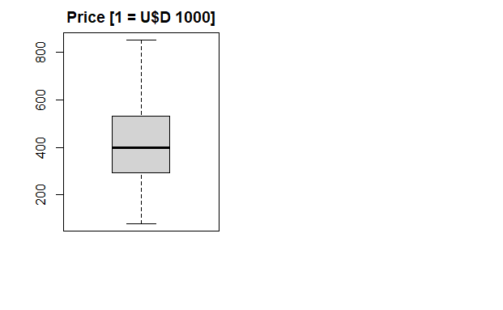

```r
#precio_filtrado <- raw_data_house %>% filter(price<1000000)
par(mfrow=c(1,2))
boxplot(dataset$price/1000,main="Price [1 = U$D 1000]")
par(mfrow=c(1,2))
```

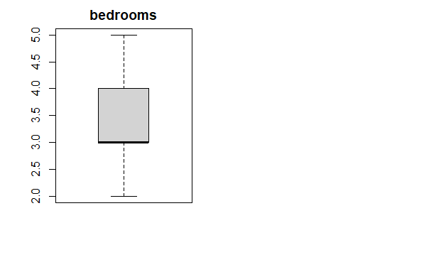

```r
boxplot(dataset$bedrooms,main="bedrooms")
```

## Boxplot de bathrooms y sqft_living

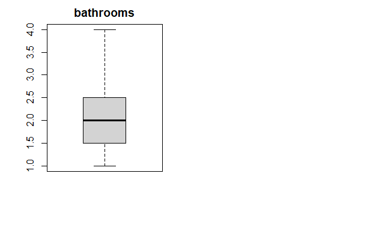

```r
par(mfrow=c(1,2))
boxplot(dataset$bathrooms,main="bathrooms")

par(mfrow=c(1,2))
```

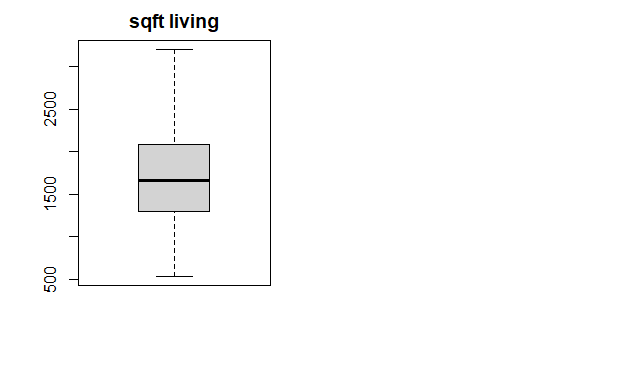

```r
boxplot(dataset$sqft_living,main="sqft living")
```

## Boxplot de sqft_lot y floors

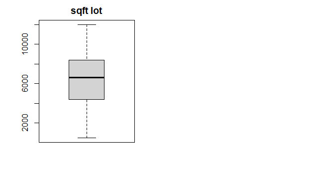

```r
par(mfrow=c(1,2))
boxplot(dataset$sqft_lot,main="sqft lot")

par(mfrow=c(1,2))
```

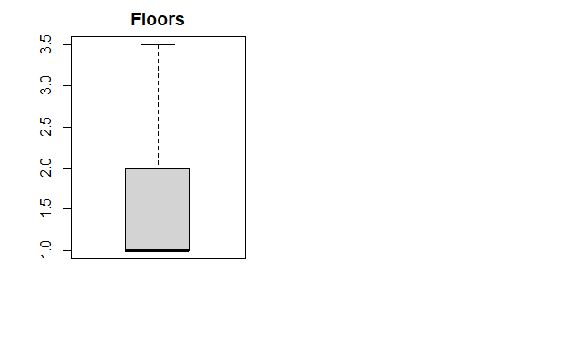

```r
boxplot(dataset$floors,main="Floors")
```

## Pie plot de renovated

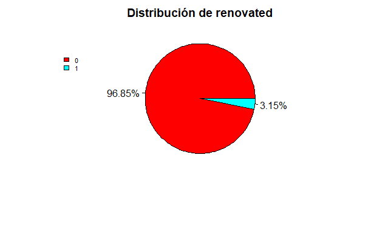

```r
workclass_1 <- table(dataset$renovated)


par(mar = c("0","1"))
lb = paste0(round(prop.table(workclass_1)*100,2),"%")
pie(workclass_1,labels = lb, col = rainbow(2),main="Distribución de renovated")
legend(-2.1,0.4,legend=names(workclass_1),cex=0.7,yjust=0.2, xjust = -0.1,
       fill = rainbow(2), bty = "n")
```

## Pie plot de has_basement

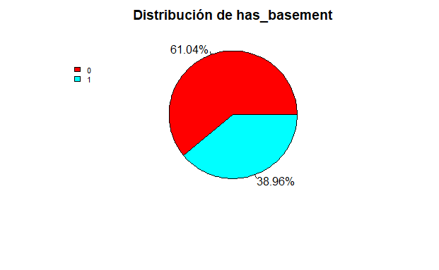

```r
workclass_2 <- table(dataset$has_basement)


par(mar = c("0","1"))
lb = paste0(round(prop.table(workclass_2)*100,2),"%")
pie(workclass_2,labels = lb, col = rainbow(2),main="Distribución de has_basement")
legend(-2.1,0.4,legend=names(workclass_2),cex=0.7,yjust=0.2, xjust = -0.1,
       fill = rainbow(2), bty = "n")
```

## Pieplot de grade

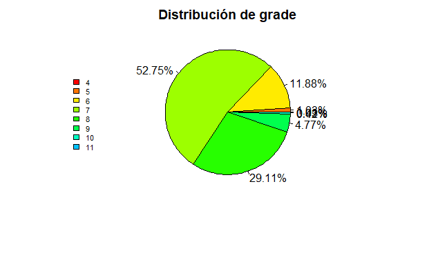

```r
workclass_3<- table(dataset$grade)


par(mar = c("0","1"))
lb = paste0(round(prop.table(workclass_3)*100,2),"%")
pie(workclass_3,labels = lb, col = rainbow(13),main="Distribución de grade")
legend(-2.1,0.4,legend=names(workclass_3),cex=0.7,yjust=0.9, xjust = -0.1,
       fill = rainbow(13), bty = "n")
```

## Pie plot de condition

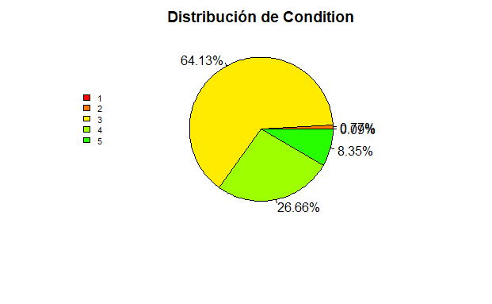

```r
workclass_4<- table(dataset$condition)


par(mar = c("0","1"))
lb = paste0(round(prop.table(workclass_4)*100,2),"%")
pie(workclass_4,labels = lb, col = rainbow(13),main="Distribución de Condition")
legend(-2.1,0.4,legend=names(workclass_4),cex=0.7,yjust=0.9, xjust = -0.1,
       fill = rainbow(13), bty = "n")
```

## Pie plot de view

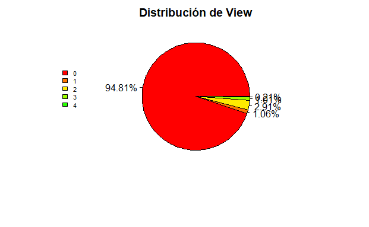

```r
workclass_5<- table(dataset$view)


par(mar = c("0","1"))
lb = paste0(round(prop.table(workclass_5)*100,2),"%")
pie(workclass_5,labels = lb, col = rainbow(13),main="Distribución de View")
legend(-2.1,0.4,legend=names(workclass_5),cex=0.7,yjust=0.9, xjust = -0.1,
       fill = rainbow(13), bty = "n")
```

## Pie plot de waterfront

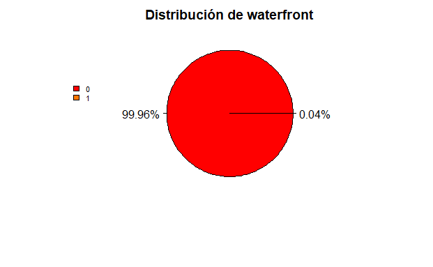

```r
workclass_6<- table(dataset$waterfront)


par(mar = c("0","1"))
lb = paste0(round(prop.table(workclass_6)*100,2),"%")
pie(workclass_6,labels = lb, col = rainbow(13),main="Distribución de waterfront")
legend(-2.1,0.4,legend=names(workclass_6),cex=0.7,yjust=0.9, xjust = -0.1,
       fill = rainbow(13), bty = "n")
```

## Boxplot de sqft above y sqft living 15

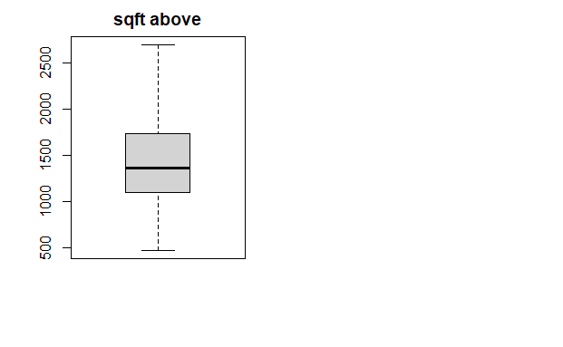

```r
par(mfrow=c(1,2))
boxplot(dataset$sqft_above,main="sqft above")

par(mfrow=c(1,2))
```

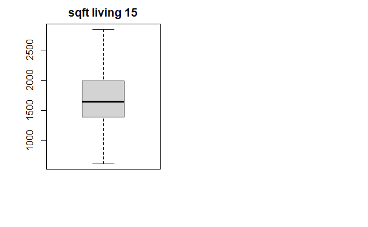

```r
boxplot(dataset$sqft_living15,main="sqft living 15")
```

## Histograma de price

```r
#Histogramas
hist(dataset$price/1000,main="Histograma de Price",xlab="Price",freq=F,col="gray",breaks=10)

x<-as.factor(dataset$price/1000)

lines(density(dataset$price/1000),col="blue",lwd=2)
```

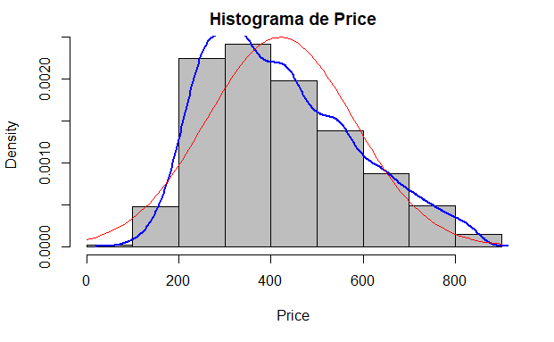

```r
curve(dnorm(x,mean=mean(dataset$price/1000),sd=sd(dataset$price/1000)),
      add=TRUE,
      col = "red")
```

## Histograma de sqft_living

```r
hist(dataset$sqft_living,main="Histograma de sqft_living",xlab="sqft_living",freq=F,col="gray",breaks=10)

x<-as.factor(dataset$sqft_living)

lines(density(dataset$sqft_living),col="blue",lwd=2)
```

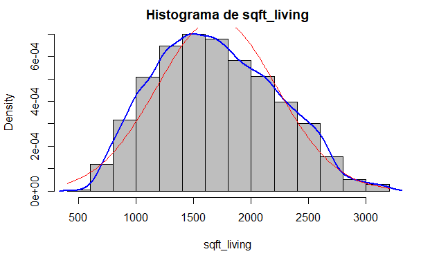

```r
curve(dnorm(x,mean=mean(dataset$sqft_living),sd=sd(dataset$sqft_living)),
      add=TRUE,
      col = "red")
```

## Histograma de sqft_lot

```r
hist(dataset$sqft_lot,main="Histograma de sqft_lot",xlab="sqft_lot",freq=F,col="gray",breaks=10)

x<-as.factor(dataset$sqft_lot)

lines(density(dataset$sqft_lot),col="blue",lwd=2)
```

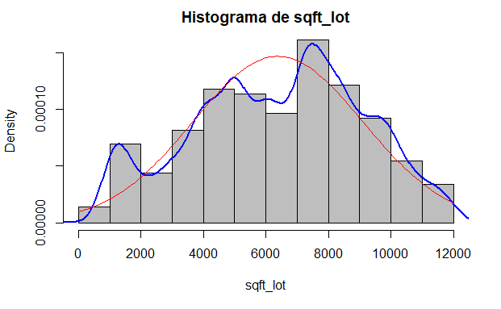

```r
curve(dnorm(x,mean=mean(dataset$sqft_lot),sd=sd(dataset$sqft_lot)),
      add=TRUE,
      col = "red")
```

## Histograma de sqft_living15

```r
hist(dataset$sqft_living15,main="Histograma de sqft_living15",xlab="sqft_living15",freq=F,col="gray",breaks=10)

x<-as.factor(dataset$sqft_living15)

lines(density(dataset$sqft_living15),col="blue",lwd=2)
```

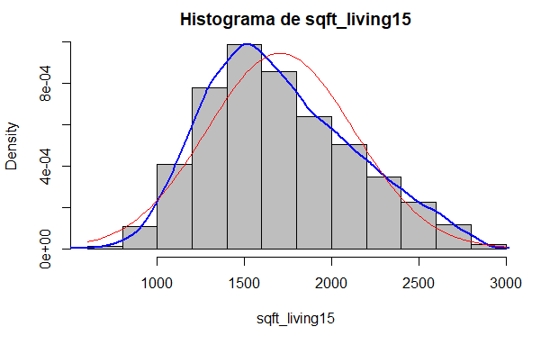

```r
curve(dnorm(x,mean=mean(dataset$sqft_living15),sd=sd(dataset$sqft_living15)),
      add=TRUE,
      col = "red")
```

## Histograma de sqft_lot15

```r
hist(dataset$sqft_lot15,main="Histograma de sqft_lot15",xlab="sqft_lot15",freq=F,col="gray",breaks=10)

x<-as.factor(dataset$sqft_lot15)

lines(density(dataset$sqft_lot15),col="blue",lwd=2)
```

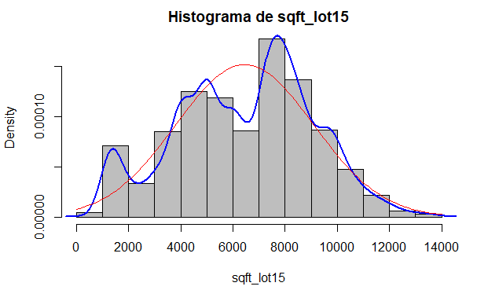

```r
curve(dnorm(x,mean=mean(dataset$sqft_lot15),sd=sd(dataset$sqft_lot15)),
      add=TRUE,
      col = "red")
```

## Histograma de yr_built

```r
hist(dataset$yr_built,main="Histograma de yr_built",xlab="yr_built",freq=F,col="gray",breaks=10)

x<-as.factor(dataset$yr_built)

lines(density(dataset$yr_built),col="blue",lwd=2)
```

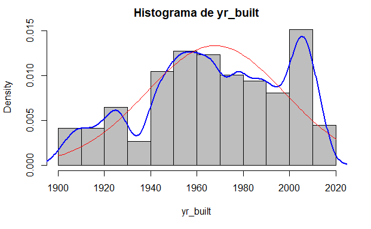

```r
curve(dnorm(x,mean=mean(dataset$yr_built),sd=sd(dataset$yr_built)),
      add=TRUE,
      col = "red")
```

# Evaluación de variable objetivo price con el resto del dataset limpio

## Distribución Price vs bathrooms

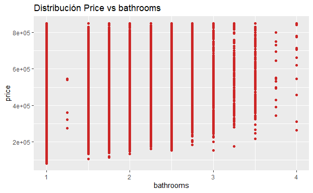

```r
ggplot(data=dataset,aes(x=bathrooms,y=price))+
  geom_point(colour=c("firebrick3"))+ggtitle("Distribución Price vs bathrooms")
```

## Distribución Price vs bedrooms

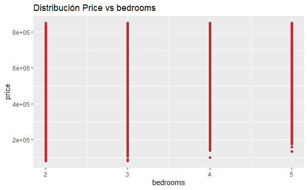

```r
ggplot(data=dataset,aes(x=bedrooms,y=price))+
  geom_point(colour=c("firebrick3"))+ggtitle("Distribución Price vs bedrooms")
```

## Distribución Price vs sqft_living

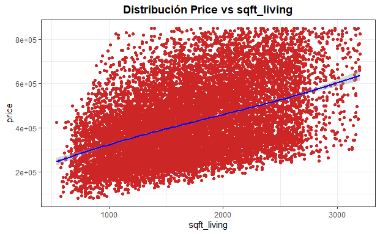

```r
ggplot(data=dataset,aes(x=sqft_living,y=price))+
  geom_point(colour=c("firebrick3"))+
  stat_smooth(method="lm",formula=y~poly(x,3),color="blue")+
theme_bw()+labs(title="Distribución Price vs sqft_living")+
  theme(plot.title=element_text(hjust=0.5,face="bold"))
```

## Distribución Price vs Sqft_living15

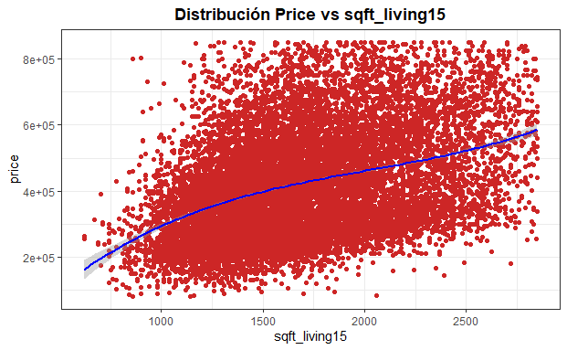

```r
ggplot(data=dataset,aes(x=sqft_living15,y=price))+
  geom_point(colour=c("firebrick3"))+
  stat_smooth(method="lm",formula=y~poly(x,3),color="blue")+
theme_bw()+labs(title="Distribución Price vs sqft_living15")+
  theme(plot.title=element_text(hjust=0.5,face="bold"))
```

## Distribución Price vs sqft_lot

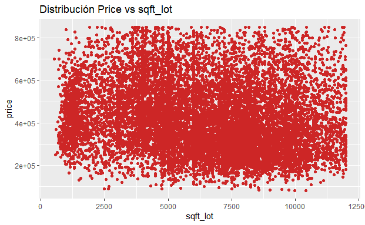

```r
ggplot(data=dataset,aes(x=sqft_lot,y=price))+
  geom_point(colour=c("firebrick3"))+ggtitle("Distribución Price vs sqft_lot")
```

## Distribución Price vs Grade

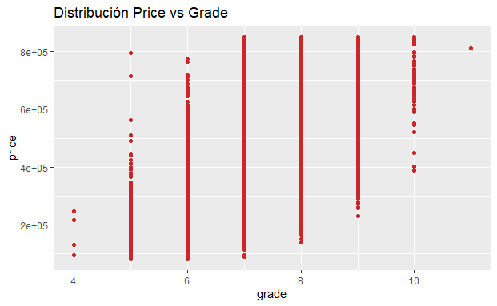

```r
ggplot(data=dataset,aes(x=grade,y=price))+
  geom_point(colour=c("firebrick3"))+ggtitle("Distribución Price vs Grade")
```

## Distribución Price vs View

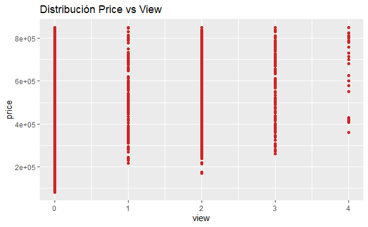

```r
ggplot(data=dataset,aes(x=view,y=price))+
  geom_point(colour=c("firebrick3"))+ggtitle("Distribución Price vs View")
```

## Distribución Price vs waterfront

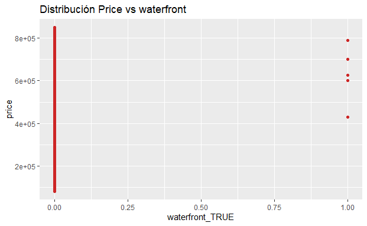

```r
ggplot(data=dataset,aes(x=waterfront_TRUE,y=price))+
  geom_point(colour=c("firebrick3"))+ggtitle("Distribución Price vs waterfront")
```

## Distribución Price vs renovated

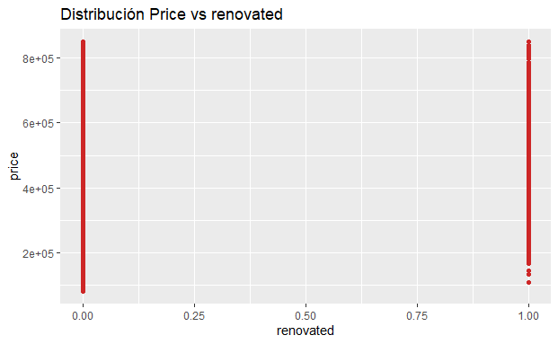

```r
ggplot(data=dataset,aes(x=renovated,y=price))+
  geom_point(colour=c("firebrick3"))+ggtitle("Distribución Price vs renovated")
```

## Matriz de correlación del dataset limpio

```r
#raw_data_house$date = NULL
data_correlation<- cor(dataset)
data_correlation
```

```
                      price     bedrooms     bathrooms sqft_living
price            1.00000000  0.161898087  0.2961818069  0.44278718
bedrooms         0.16189809  1.000000000  0.4109562227  0.59471395
bathrooms        0.29618181  0.410956223  1.0000000000  0.65309216
sqft_living      0.44278718  0.594713948  0.6530921604  1.00000000
sqft_lot        -0.16613721  0.231933159 -0.1328120720  0.16047483
floors           0.17346891  0.066230444  0.4931091422  0.22130966
view             0.19823457  0.012376058  0.0507129329  0.12124223
condition        0.09183875  0.053847240 -0.1278022857 -0.01498047
grade            0.47253945  0.214259472  0.5450275509  0.53667209
sqft_above       0.29012846  0.426868806  0.5681932477  0.74048961
yr_built        -0.09979427  0.107262367  0.5568915286  0.26024759
sqft_living15    0.37536816  0.350132303  0.4660458564  0.65210879
sqft_lot15      -0.17873027  0.210666393 -0.1342879204  0.13504689
renovated        0.08581189  0.010373693  0.0144332366  0.02561953
has_basement     0.24224709  0.164750421  0.1610867873  0.29668623
waterfront_TRUE  0.02478015 -0.004450028 -0.0003914234  0.01051751
                   sqft_lot       floors        view   condition
price           -0.16613721  0.173468906  0.19823457  0.09183875
bedrooms         0.23193316  0.066230444  0.01237606  0.05384724
bathrooms       -0.13281207  0.493109142  0.05071293 -0.12780229
sqft_living      0.16047483  0.221309658  0.12124223 -0.01498047
sqft_lot         1.00000000 -0.498705424  0.00663834  0.16566140
floors          -0.49870542  1.000000000 -0.02434604 -0.27254664
view             0.00663834 -0.024346037  1.00000000  0.01870181
condition        0.16566140 -0.272546637  0.01870181  1.00000000
grade           -0.10399970  0.432521329  0.08643745 -0.17177096
sqft_above       0.10362099  0.489972685  0.01933356 -0.15301080
yr_built        -0.12898742  0.515904320 -0.08434739 -0.35002638
sqft_living15    0.20056402  0.160915939  0.16234578 -0.09218317
sqft_lot15       0.89743787 -0.483216698  0.01118859  0.16055978
renovated       -0.01482676 -0.008400128  0.04024149 -0.05929524
has_basement    -0.03119928 -0.268664744  0.12699799  0.10500524
waterfront_TRUE  0.01390541 -0.008073296  0.15065068  0.01084792
                       grade    sqft_above    yr_built sqft_living15
price            0.472539450  0.2901284608 -0.09979427   0.375368155
bedrooms         0.214259472  0.4268688060  0.10726237   0.350132303
bathrooms        0.545027551  0.5681932477  0.55689153   0.466045856
sqft_living      0.536672089  0.7404896118  0.26024759   0.652108792
sqft_lot        -0.103999704  0.1036209884 -0.12898742   0.200564017
```

[output cut: 13 more lines]

```
bedrooms         0.21066639  0.010373693  0.164750421   -0.0044500284
bathrooms       -0.13428792  0.014433237  0.161086787   -0.0003914234
sqft_living      0.13504689  0.025619535  0.296686233    0.0105175085
sqft_lot         0.89743787 -0.014826758 -0.031199284    0.0139054098
floors          -0.48321670 -0.008400128 -0.268664744   -0.0080732962
view             0.01118859  0.040241493  0.126997990    0.1506506755
condition        0.16055978 -0.059295236  0.105005243    0.0108479152
grade           -0.09772884 -0.017036243  0.056100031   -0.0062592835
sqft_above       0.07985447  0.003843046 -0.318527507    0.0008483693
yr_built        -0.10615405 -0.195255496 -0.139655742   -0.0162199940
sqft_living15    0.21078795 -0.043678307  0.065755058    0.0024334731
sqft_lot15       1.00000000 -0.010872327 -0.028720226    0.0246093655
renovated       -0.01087233  1.000000000  0.012100318    0.0182980167
has_basement    -0.02872023  0.012100318  1.000000000    0.0081793791
waterfront_TRUE  0.02460937  0.018298017  0.008179379    1.0000000000
```

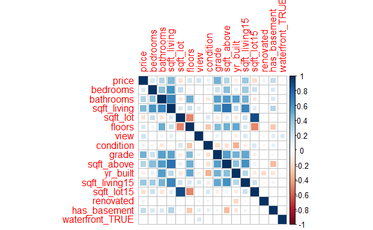

```r
corrplot(data_correlation,method="square")
```

##Calculo de VIF de cada variable

```r
mlr <- lm(formula=price ~ ., data = dataset)
summary(mlr)
```

```
Call:
lm(formula = price ~ ., data = dataset)

Residuals:
    Min      1Q  Median      3Q     Max
-442967  -79691   -5521   73501  508669

Coefficients:
                  Estimate Std. Error t value Pr(>|t|)
(Intercept)      4.184e+06  9.205e+04  45.448  < 2e-16 ***
bedrooms        -1.308e+04  1.647e+03  -7.942 2.14e-15 ***
bathrooms        1.422e+04  2.562e+03   5.552 2.88e-08 ***
sqft_living      5.270e+01  5.688e+00   9.266  < 2e-16 ***
sqft_lot        -5.562e+00  8.421e-01  -6.605 4.11e-11 ***
floors           1.372e+04  2.983e+03   4.598 4.30e-06 ***
view             1.987e+04  2.064e+03   9.627  < 2e-16 ***
condition        2.061e+04  1.628e+03  12.664  < 2e-16 ***
grade            8.542e+04  1.733e+03  49.305  < 2e-16 ***
sqft_above       1.703e+01  6.346e+00   2.683   0.0073 **
yr_built        -2.343e+03  4.799e+01 -48.816  < 2e-16 ***
sqft_living15    6.292e+01  3.339e+00  18.844  < 2e-16 ***
sqft_lot15      -7.878e+00  8.464e-01  -9.308  < 2e-16 ***
renovated        7.997e+03  5.809e+03   1.377   0.1686
has_basement     3.344e+04  3.963e+03   8.438  < 2e-16 ***
waterfront_TRUE  9.799e+04  5.158e+04   1.900   0.0575 .
---
Signif. codes:  0 ‘***’ 0.001 ‘**’ 0.01 ‘*’ 0.05 ‘.’ 0.1 ‘ ’ 1

Residual standard error: 113900 on 13894 degrees of freedom
Multiple R-squared:  0.494, Adjusted R-squared:  0.4935
F-statistic: 904.3 on 15 and 13894 DF,  p-value: < 2.2e-16
```

```r
library("car")
vif(mlr)
```

```
       bedrooms       bathrooms     sqft_living        sqft_lot
       1.670896        2.899871        9.401512        5.631023
         floors            view       condition           grade
       2.860846        1.096645        1.228252        1.984044
     sqft_above        yr_built   sqft_living15      sqft_lot15
       9.573165        2.205492        2.134813        5.327202
      renovated    has_basement waterfront_TRUE
       1.103864        4.007224        1.025640
```

Como se puede ver los valores que tienen una alta posibilidad de colinealidad son sqft_living, sqft_lot, sqft_above y sqft_lot15

# Selección de modelos y regularización

## Best Subset Selection

Compara todos los posibles modelos usando un conjunto especifico de predictores. Muestra los modelos con mejores ajustes que contienen un predictor, dos predictores,…, n predictores. Al final contamos con un numero de modelos y sus respectivos resumenes estadisticos. La ventaja es que es conceptualmente claro. La desventaja es que es computacionalmente inviable, hay muchos modelos a ejecutar. Para el presente caso son 15 predictores lo que equivaldría a 2^15 = 32.768 modelos

```r
regsubset.full <- regsubsets(price ~ ., data = dataset)
```

## Sumario de regsubset

```r
sumario.regsubset <- summary(regsubset.full)
```

## Stepwise Selection

El metodo selecciona un modelo agregando y eliminando predictores individuales, de una a la vez, basado en su significancia estadística.

El estadístico Cp compara la precision y el sesgo del modelo completo con modelos que incluyan un subconjunto de predictores.

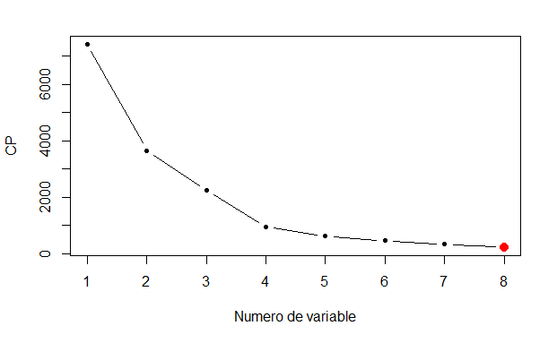

```r
plot(sumario.regsubset$cp,xlab = "Numero de variable",ylab="CP",pch = 20, type="b")
value.min <- which.min(sumario.regsubset$cp)

points(value.min,sumario.regsubset$cp[value.min],col = "red",cex = 2,pch = 20)
```

Ploteo de Cp

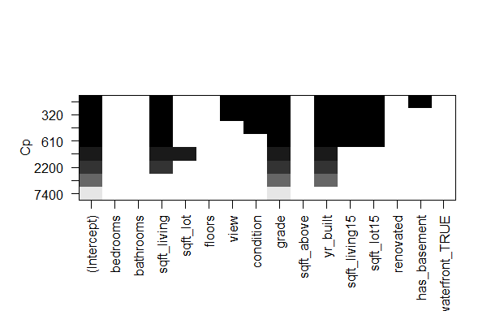

```r
plot(regsubset.full,scale="Cp")
```

Coeficiente de Determinacion R^2

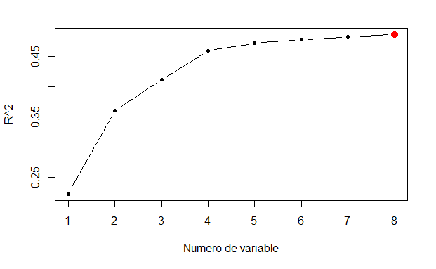

```r
plot(sumario.regsubset$rsq,xlab = "Numero de variable",ylab="R^2",pch = 20, type="b")
value.max <- which.max(sumario.regsubset$rsq)

points(value.min,sumario.regsubset$rsq[value.max],col = "red",cex = 2,pch = 20)
```

Ploteo de R^2

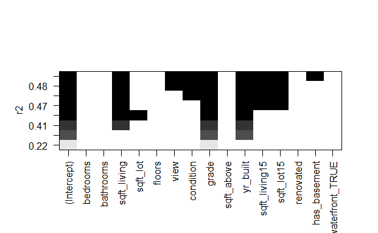

```r
plot(regsubset.full,scale="r2")
```

Residual Sum Square (RSS)

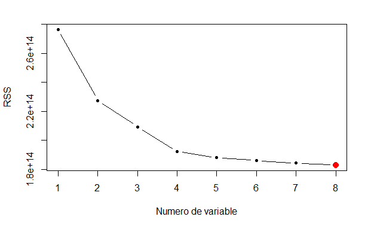

```r
plot(sumario.regsubset$rss,xlab = "Numero de variable",ylab="RSS",pch = 20, type="b")
value.min <- which.min(sumario.regsubset$rss)

points(value.min,sumario.regsubset$rss[value.min],col = "red",cex = 2,pch = 20)
```

Bayesian Information Criterion(BIC)

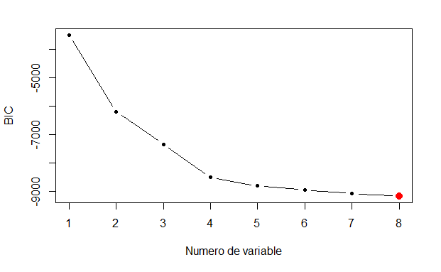

```r
plot(sumario.regsubset$bic,xlab = "Numero de variable",ylab="BIC",pch = 20, type="b")
value.min <- which.min(sumario.regsubset$bic)

points(value.min,sumario.regsubset$bic[value.min],col = "red",cex = 2,pch = 20)
```

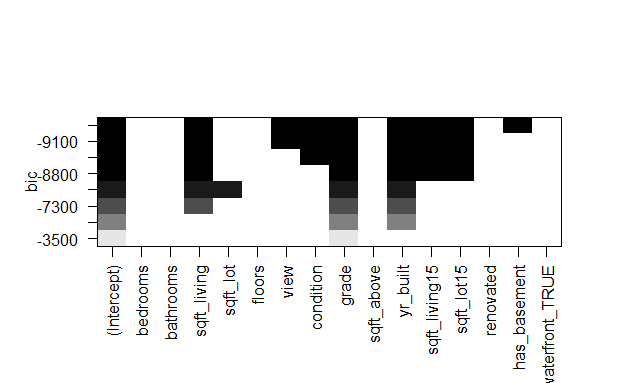

```r
plot(regsubset.full,scale="bic")
```

R^2 Ajustado

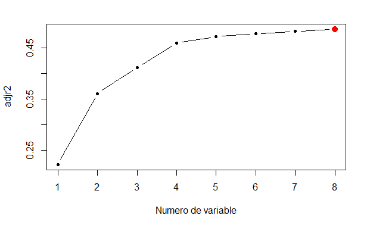

```r
plot(sumario.regsubset$adjr2,xlab = "Numero de variable",ylab="adjr2",pch = 20, type="b")
value.max <- which.max(sumario.regsubset$adjr2)

points(value.min,sumario.regsubset$adjr2[value.max],col = "red",cex = 2,pch = 20)
```

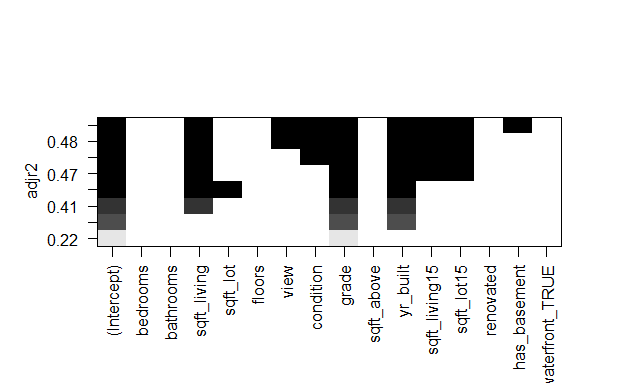

```r
plot(regsubset.full,scale="adjr2")
```

Coeficientes

```r
coef(regsubset.full,8)
```

```
  (Intercept)   sqft_living          view     condition         grade
3762196.93752      62.80365   21789.35929   19487.04878   90521.27712
     yr_built sqft_living15    sqft_lot15  has_basement
  -2131.60536      64.73333     -15.36831   21564.17900
```

Cp, AIC, BIC y R^2 ajustado son tecnicas que ajustan el error de entrenamiento para el tamaño del modelo y pueden ser usados para seleccionar entre un conjunto de modelos con diferentes numeros de variables.

## Conjunto de validación

Para el caso de estudio de House Price, se debera proceder a dividir las observaciones en dos: primero en entrenamiento (train, 70 %) y prueba (test, 30 %). Las proporciones pueden variar.

```r
index <- createDataPartition(dataset$price, p = 0.7, list = FALSE)
data.train <- dataset[index, ]
data.test <- dataset[-index, ]
```

```r
set.seed(10)
model.fwd <- regsubsets(price ~., data = data.train, nvmax = 11, method = "forward")
summary(model.fwd)
```

```
Subset selection object
Call: regsubsets.formula(price ~ ., data = data.train, nvmax = 11,
    method = "forward")
15 Variables  (and intercept)
                Forced in Forced out
bedrooms            FALSE      FALSE
bathrooms           FALSE      FALSE
sqft_living         FALSE      FALSE
sqft_lot            FALSE      FALSE
floors              FALSE      FALSE
view                FALSE      FALSE
condition           FALSE      FALSE
grade               FALSE      FALSE
sqft_above          FALSE      FALSE
yr_built            FALSE      FALSE
sqft_living15       FALSE      FALSE
sqft_lot15          FALSE      FALSE
renovated           FALSE      FALSE
has_basement        FALSE      FALSE
waterfront_TRUE     FALSE      FALSE
1 subsets of each size up to 11
Selection Algorithm: forward
          bedrooms bathrooms sqft_living sqft_lot floors view condition
1  ( 1 )  " "      " "       " "         " "      " "    " "  " "
2  ( 1 )  " "      " "       " "         " "      " "    " "  " "
3  ( 1 )  " "      " "       "*"         " "      " "    " "  " "
4  ( 1 )  " "      " "       "*"         " "      " "    " "  " "
5  ( 1 )  " "      " "       "*"         " "      " "    " "  " "
6  ( 1 )  " "      " "       "*"         " "      " "    " "  "*"
7  ( 1 )  " "      " "       "*"         " "      " "    "*"  "*"
8  ( 1 )  " "      " "       "*"         " "      " "    "*"  "*"
9  ( 1 )  " "      " "       "*"         " "      "*"    "*"  "*"
10  ( 1 ) "*"      " "       "*"         " "      "*"    "*"  "*"
11  ( 1 ) "*"      "*"       "*"         " "      "*"    "*"  "*"
          grade sqft_above yr_built sqft_living15 sqft_lot15 renovated
1  ( 1 )  "*"   " "        " "      " "           " "        " "
2  ( 1 )  "*"   " "        "*"      " "           " "        " "
3  ( 1 )  "*"   " "        "*"      " "           " "        " "
4  ( 1 )  "*"   " "        "*"      " "           "*"        " "
5  ( 1 )  "*"   " "        "*"      "*"           "*"        " "
6  ( 1 )  "*"   " "        "*"      "*"           "*"        " "
7  ( 1 )  "*"   " "        "*"      "*"           "*"        " "
8  ( 1 )  "*"   " "        "*"      "*"           "*"        " "
9  ( 1 )  "*"   " "        "*"      "*"           "*"        " "
10  ( 1 ) "*"   " "        "*"      "*"           "*"        " "
11  ( 1 ) "*"   " "        "*"      "*"           "*"        " "
          has_basement waterfront_TRUE
1  ( 1 )  " "          " "
2  ( 1 )  " "          " "
3  ( 1 )  " "          " "
4  ( 1 )  " "          " "
5  ( 1 )  " "          " "
6  ( 1 )  " "          " "
7  ( 1 )  " "          " "
8  ( 1 )  "*"          " "
9  ( 1 )  "*"          " "
10  ( 1 ) "*"          " "
11  ( 1 ) "*"          " "
```

```r
#val.errors = rep(NA,11)
#x.test <- model.matrix(price ~., data = data.test)
#for(i in 1:11)
#{
#coeficientes <- coef(model.fwd, id=i)
#predictors <- x.test[,names(coeficientes)]
#val.errors[i] <- mean((data.test$price[-indices] - predictions)^2)
  # modelo <- lm(price ~poly(sqft_living15,i),data=dataset[-indices,])
  #predicciones <- predict(object = modelo,newdata=dataset[-indices,])
  #cv_MSE[i] <- mean((dataset$price[-indices]-predicciones)^2)
#}
#val.errors
```

## Validación cruzada

```r
set.seed(7)
folds <- sample(rep(1:8, length = nrow(dataset)))
folds
```

[output not shown]

[output cut: 16 more lines]

```r
table(folds)
```

```
folds
   1    2    3    4    5    6    7    8
1739 1739 1739 1739 1739 1739 1738 1738
```

```r
#cv.errors <- matrix(NA,7,8)
#for(k in 1:7) {

#model.fwd <- regsubsets(price ~., data = dataset[folds !=k,], nvmax = 8, method = "forward")
#for(i in 1:8) {
#predictions <- predict(model.fwd, dataset[folds == k,], id = i)
#cv.errors[k,i] <- mean((dataset$price[folds == k] - predictions)^2)
#}
#}
#rmse.cv <- sqrt(apply(cv.errors, 2, mean))
#rmse.cv
```

## Ridge

Aplicamos la funcion model.matrix() para la transformacion de datos dado que glmnet() solo acepta valores numericos.

```r
x.ridge <- model.matrix(price ~. , dataset)[,-1]
y.ridge <- dataset$price
```

```r
grid <- 10^seq(10,-2,length = 100)
ridge.model <- glmnet(x.ridge, y.ridge, alpha = 0, lambda = grid)
dim(coef(ridge.model))
```

```
[1]  16 100
```

## Ploteo de Ridge

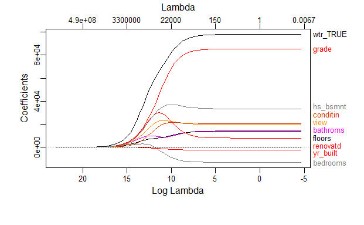

```r
library("plotmo")
plot_glmnet(ridge.model)
```

Una vez calculada la regresion de Ridge, debemos realizar la predicción de valores para obtener los coeficientes para el nuevo valor de λ. En este caso probamos con 10, pero hay que recordar que tienen 100 valores producto del uso de la grilla.

```r
predict(ridge.model, s = 10, type = "coefficients")
```

```
16 x 1 sparse Matrix of class "dgCMatrix"
                           s1
(Intercept)      4.182937e+06
bedrooms        -1.307510e+04
bathrooms        1.421842e+04
sqft_living      5.270911e+01
sqft_lot        -5.564088e+00
floors           1.371728e+04
view             1.986800e+04
condition        2.061521e+04
grade            8.540945e+04
sqft_above       1.702506e+01
yr_built        -2.342432e+03
sqft_living15    6.292234e+01
sqft_lot15      -7.876761e+00
renovated        8.007773e+03
has_basement     3.343712e+04
waterfront_TRUE  9.797825e+04
```

## Validación cruzada

Para el caso de la validacion cruzada realizamos una división de los datos en 50 % para entrenamiento y 50 % para test.

```r
set.seed(2)
indices <- sample(c(TRUE,FALSE), nrow(dataset), replace = TRUE)
y.test <- y.ridge[-indices]
```

El paquete glmnet() posee su propia instruccion para la validación cruzada: cv.glmnet().

```r
ridge.model.cv <- cv.glmnet(x.ridge[indices,], y.ridge[indices], alpha = 0) # Por defecto, 10-fold
coef(ridge.model.cv)
```

```
16 x 1 sparse Matrix of class "dgCMatrix"
                           s1
(Intercept)      3.223660e+06
bedrooms        -1.093438e+04
bathrooms        1.246075e+04
sqft_living      4.855597e+01
sqft_lot        -5.541748e+00
floors           6.989965e+03
view             2.434277e+04
condition        2.103327e+04
grade            6.968843e+04
sqft_above       2.199909e+01
yr_built        -1.796732e+03
sqft_living15    6.366444e+01
sqft_lot15      -7.657671e+00
renovated        1.800946e+04
has_basement     3.299079e+04
waterfront_TRUE  5.286651e+04
```

Ploteo del modelo de ridge

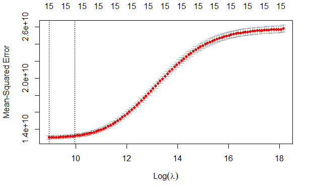

```r
plot(ridge.model.cv)
```

En la figura se pueden observar dos líneas punteadas verticales, en este caso muy proximas entre si. La de la izquierda representa el mínimo de la validacion cruzada. La de la derecha representa el error estandar.

En vez de usar un λ arbitrario, es mejor basarnos en la validacion cruzada para elegir el parametro de tuning.

```r
bestlam <- ridge.model.cv$lambda.min
bestlam
```

```
[1] 7694.194
```

A continuacion, utiizaremos el λ mas bajo obtenido del calculo realizado en la validación cruzada para la prediccion basada en los datos de testing.

```r
ridge.pred <- predict(ridge.model, s = bestlam, newx = x.ridge[-indices,])
```

## RMSE de Ridge

```r
rmse.ridge <- sqrt(mean((ridge.pred - y.test)^2))
rmse.ridge
```

```
[1] 113971.5
```

Finalmente, reajustamos el modelo de regresion de ridge usando el dataset completo para estudiar los coeficientes. Para ello, usamos el valor de λ calculado por la validacion cruzada.

```r
out <- glmnet(x.ridge, y.ridge, alpha = 0)
predict(out, type = "coefficients", s = bestlam)
```

```
16 x 1 sparse Matrix of class "dgCMatrix"
                           s1
(Intercept)     3758899.97660
bedrooms         -11264.59942
bathrooms         11653.40691
sqft_living          49.99428
sqft_lot             -5.76791
floors            11982.90120
view              21182.67902
condition         21367.32870
grade             78356.39409
sqft_above           21.65164
yr_built          -2102.43680
sqft_living15        61.66690
sqft_lot15           -7.57271
renovated         14760.21525
has_basement      36018.26596
waterfront_TRUE   90845.10497
```

```r
x <- model.matrix(price ~ ., dataset)[,-1]
y <- dataset$price
```

Aplicamos la función glmnet con el parámetro alpha igual a 1 para indicar que utilizaremos la regresión Lasso

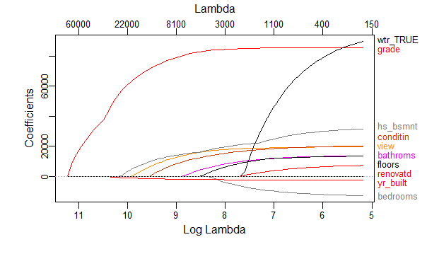

```r
library("glmnet")
lasso.model <- glmnet(x,y,alpha = 1)

plot_glmnet(lasso.model)
```

## Validación cruzada

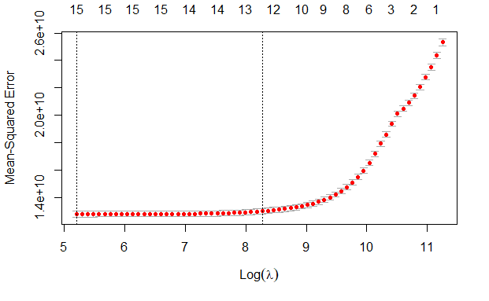

```r
indices <- sample(c(TRUE,FALSE),nrow(dataset),replace=TRUE)
cv.out<- cv.glmnet(x[indices,],y[indices],alpha=1)
plot(cv.out)
```

En el caso de la regresion Lasso, la figura nos indica que el modelo base, el valor minimo de la validacion cruzada, es de tamaño 15, mientras que el error estandar es de tamaño 12. Por conseguiente, podemos realizar nuestra eleccion del tamaño del modelo basandonos en esto.

Mostramos los coeficientes calculados

```r
coef(cv.out)
```

```
16 x 1 sparse Matrix of class "dgCMatrix"
                           s1
(Intercept)      3.672122e+06
bedrooms        -3.151942e+03
bathrooms        8.287822e+03
sqft_living      5.431045e+01
sqft_lot        -6.511933e+00
floors           3.803482e+03
view             1.551553e+04
condition        1.305553e+04
grade            8.648536e+04
sqft_above       .
yr_built        -2.058910e+03
sqft_living15    5.747778e+01
sqft_lot15      -6.106238e+00
renovated        .
has_basement     1.594536e+04
waterfront_TRUE  .
```

En lugar de usar un parametro de tuning arbitrario, utilizamos el más bajo arrojado por la validacion cruzada.

```r
bestlam <- cv.out$lambda.min
bestlam
```

```
[1] 181.8887
```

A continuacion, predecimos el lambda junto a los datos de prueba.

```r
lasso.pred <- predict(lasso.model,s=bestlam,newx=x[-indices,])
value_2 <- mean((lasso.pred-y[-indices])^2)
```

## RMSE de Lasso

```r
rmse_2 <- sqrt(value_2)
rmse_2
```

```
[1] 113803.7
```

Se puede observar que el RMSE de Lasso es el menor de todos, por lo tanto es el más efectivo para la selección de variables. El siguiente paso es dividir el dataset en diferentes clústers.

# Selección final de variables

```r
dataset_clustering <- dataset
dataset_clustering$bedrooms = NULL
dataset_clustering$sqft_above = NULL
dataset_clustering$waterfront_TRUE = NULL
dataset_clustering$yr_built = NULL
dataset_clustering$has_basement = NULL
dataset_clustering$renovated = NULL
dataset_clustering$condition = NULL
dataset_clustering$view = NULL
dataset_clustering$sqft_living = NULL
dataset_clustering$sqft_lot = NULL
```

# Clustering

## Dimensiones de dataset para clustering

```r
dimensiones_clustering <- dim(dataset_clustering)
dimensiones_clustering
```

```
[1] 13910     6
```

## Sumario de dataset para clustering

```r
sumario_clustering <- summary(dataset_clustering)
sumario_clustering
```

```
     price          bathrooms         floors          grade
 Min.   : 81000   Min.   :1.000   Min.   :1.000   Min.   : 4.000
 1st Qu.:294000   1st Qu.:1.500   1st Qu.:1.000   1st Qu.: 7.000
 Median :397000   Median :2.000   Median :1.000   Median : 7.000
 Mean   :419856   Mean   :1.913   Mean   :1.433   Mean   : 7.259
 3rd Qu.:529430   3rd Qu.:2.500   3rd Qu.:2.000   3rd Qu.: 8.000
 Max.   :850000   Max.   :4.000   Max.   :3.500   Max.   :11.000
 sqft_living15    sqft_lot15
 Min.   : 620   Min.   :  651
 1st Qu.:1390   1st Qu.: 4536
 Median :1650   Median : 6733
 Mean   :1706   Mean   : 6454
 3rd Qu.:1990   3rd Qu.: 8314
 Max.   :2850   Max.   :14000
```

## Estructura de dataset para clustering

```r
estructura_clustering <- str(dataset_clustering)
```

```
'data.frame':   13910 obs. of  6 variables:
 $ price        : num  221900 538000 180000 604000 510000 ...
 $ bathrooms    : num  1 2.25 1 3 2 2.25 1.5 1 2.5 1 ...
 $ floors       : num  1 2 1 1 1 2 1 1 2 1 ...
 $ grade        : int  7 7 6 7 8 7 7 7 7 7 ...
 $ sqft_living15: int  1340 1690 2720 1360 1800 2238 1650 1780 2390 1330 ...
 $ sqft_lot15   : int  5650 7639 8062 5000 7503 6819 9711 8113 7570 6000 ...
```

```r
estructura_clustering
```

## Factores de dataset para clustering

```r
factores_dataset <- dataset_clustering
factores_dataset$price <- as.factor(dataset_clustering$price)
factores_dataset$bathrooms <- as.factor(dataset_clustering$bathrooms)
factores_dataset$floors <- as.factor(dataset_clustering$floors)
factores_dataset$grade <- as.factor(dataset_clustering$grade)
factores_dataset$sqft_living15 <- as.factor(dataset_clustering$sqft_living15)
factores_dataset$sqft_lot15 <- as.factor(dataset_clustering$sqft_lot15)

summary(factores_dataset)
```

```
     price         bathrooms    floors         grade      sqft_living15
 350000 :  130   2.5    :3242   1  :7761   7      :7338   1540   :  172
 450000 :  126   1      :3206   1.5:1350   8      :4049   1440   :  168
 325000 :  120   1.75   :2256   2  :4225   6      :1653   1500   :  161
 425000 :  120   2      :1481   2.5:  55   9      : 664   1560   :  148
 3e+05  :  106   2.25   :1390   3  : 513   5      : 143   1410   :  142
 4e+05  :  106   1.5    :1164   3.5:   6   10     :  58   1460   :  140
 (Other):13202   (Other):1171              (Other):   5   (Other):12979
   sqft_lot15
 5000   :  323
 4000   :  285
 6000   :  228
 7200   :  174
 7500   :  119
 4800   :  111
 (Other):12670
```

Realizamos una transformación de las variables categoricas (encoding). Inmediatamente después eliminamos las columnas categóricas.

```r
library("fastDummies")
dataset_clustering <- dummy_cols(dataset_clustering, c("bathrooms","floors","grade"),
remove_first_dummy = TRUE)
dataset_clustering[,c("bathrooms","floors","grade")] <- NULL
```

Una vez finalizada la limpieza y transformacion de los datos, se debe realizar la estandarizacion de los mismos mediante la función scale().

```r
dataset.scaled <- scale(dataset_clustering)
```

Mediante la funcion kmeans() calculamos los clusteres.

```r
k.means.fit <- kmeans(dataset.scaled, centers = 4, nstart = 100)
print(k.means.fit)
```

```
K-means clustering with 4 clusters of sizes 7203, 4392, 1796, 519

Cluster means:
       price sqft_living15 sqft_lot15 bathrooms_1.5 bathrooms_1.25
1 -0.1694836    -0.1953762  0.1087652    0.10039244    0.003008962
2  0.5620201     0.7526300 -0.0188625   -0.15089803    0.005059984
3 -0.7933136    -0.8851740  0.1110631   -0.06894748   -0.018961989
4  0.3414044    -0.5943802 -1.7342212    0.12224866   -0.018961989
  bathrooms_1.75 bathrooms_2 bathrooms_2.5 bathrooms_2.25 bathrooms_2.75
1      0.1245741  0.07835916    -0.1900551    -0.04017159    -0.02122632
2     -0.1014913 -0.10453672     0.4977844     0.15647710     0.12008134
3     -0.1544936 -0.04733138    -0.5314973    -0.32761870    -0.18006247
4     -0.3354270 -0.03909176     0.2644842     0.36707465    -0.09848143
  bathrooms_3 bathrooms_3.5 bathrooms_3.25 bathrooms_3.75   bathrooms_4
1  -0.0207885   -0.08064105    -0.08449961   -0.009849073  0.0012186080
```

[output cut: 56 more lines]

A su vez, y mediante print(), podemos mostrar una serie de resultados tales como la suma de los cuadrados intercluster para cada cluster y el total. Finalmente, muestra las variables que nos pueden ser utiles para realizar numerosas operaciones.

Mediante la variable size podemos ver cuantos objetos fueron asignados a cada cluster.

```r
 k.means.fit$size
```

```
[1] 7203 4392 1796  519
```

```r
k.means.fit$centers
```

```
       price sqft_living15 sqft_lot15 bathrooms_1.5 bathrooms_1.25
1 -0.1694836    -0.1953762  0.1087652    0.10039244    0.003008962
2  0.5620201     0.7526300 -0.0188625   -0.15089803    0.005059984
3 -0.7933136    -0.8851740  0.1110631   -0.06894748   -0.018961989
4  0.3414044    -0.5943802 -1.7342212    0.12224866   -0.018961989
  bathrooms_1.75 bathrooms_2 bathrooms_2.5 bathrooms_2.25 bathrooms_2.75
1      0.1245741  0.07835916    -0.1900551    -0.04017159    -0.02122632
2     -0.1014913 -0.10453672     0.4977844     0.15647710     0.12008134
3     -0.1544936 -0.04733138    -0.5314973    -0.32761870    -0.18006247
4     -0.3354270 -0.03909176     0.2644842     0.36707465    -0.09848143
  bathrooms_3 bathrooms_3.5 bathrooms_3.25 bathrooms_3.75   bathrooms_4
1  -0.0207885   -0.08064105    -0.08449961   -0.009849073  0.0012186080
2   0.0621503    0.15231491     0.10868608    0.025702343 -0.0007799221
3  -0.1391936   -0.09400997    -0.10684040   -0.014180892 -0.0305840881
4   0.2442528    0.15555354     0.62271051   -0.031739750  0.0955237125
   floors_1.5   floors_2  floors_2.5   floors_3  floors_3.5    grade_5
1  0.07500134 -0.1895287 -0.04530602 -0.1956768 -0.02077257 -0.1019137
2 -0.14017344  0.6342038  0.10751176 -0.1956768 -0.02077257 -0.1019137
3  0.13672267 -0.5999264 -0.06300318 -0.1956768 -0.02077257  0.6874071
4 -0.32783586 -0.6604621 -0.06300318  5.0487625  0.53596421 -0.1019137
    grade_6    grade_7    grade_8    grade_9     grade_10    grade_11
1 -0.367222  0.9435530 -0.6395411 -0.2225833 -0.064705641 -0.00847884
2 -0.367222 -1.0347434  1.2006612  0.4307254  0.133158446  0.01837468
3  2.476908 -1.0566337 -0.6407635 -0.2238855 -0.064705641 -0.00847884
4 -0.367222 -0.6822833  0.9327979  0.2189208 -0.004905265 -0.00847884
```

## Validación de los clúster

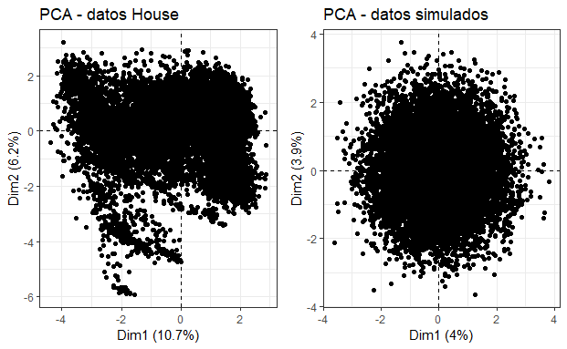

```r
library("ggpubr")
library("factoextra")
data.simulated <- purrr::map_df(dataset_clustering, .f = function(x){ runif(n = length(x), min = min(x),
max = max(x)) })
data.simulated.scaled <- scale(data.simulated)

pca_data_house <- prcomp(dataset.scaled)

pca_data_simulated <- prcomp(data.simulated.scaled)

p1 <- fviz_pca_ind(X = pca_data_house,
geom = "point", title = "PCA - datos House",
pallete = "jco") +
theme_bw() + theme(legend.position = "bottom")

p2 <- fviz_pca_ind(X = pca_data_simulated, geom = "point",
title = "PCA - datos simulados", pallete = "jco") +
theme_bw() + theme(legend.position = "bottom")

ggarrange(p1, p2, common.legend = TRUE)
```

Una representacion grafica nos permitira comprobar que el dataset HousePrice si contiene grupos reales mientras que los simulados no deberian.

```r
'''
k.means.fit <- kmeans(x = dataset.scaled, centers = 4)
p1 <- fviz_cluster(object = k.means.fit, data = dataset.scaled,
ellipse.type = "norm", geom = "point", main = "Datos House Price",
stand = FALSE, palette = "jco") +
theme_bw() + theme(legend.position = "none")
k.means.simulados <- kmeans(x = data.simulated.scaled, centers = 4)
p2 <- fviz_cluster(object = k.means.simulados, data = data.simulated,
ellipse.type = "norm", geom = "point",
main = "Datos Simulados", stand = FALSE, palette = "jco") +
theme_bw() + theme(legend.position = "none")
# Hierarchical clustering
p3 <- fviz_dend(x = hclust(dist(dataset.scaled)), k = 4, k_colors = "jco",
show_labels = FALSE, main = "Datos iris")
p4 <- fviz_dend(x = hclust(dist(data.simulated.scaled)), k = 4, k_colors = "jco",
show_labels = FALSE, main = "Datos simulados")
ggarrange(p1, p2)
'''
```

[output not shown]

```r
p3 <- fviz_dend(x = hclust(dist(dataset.scaled)), k = 4, k_colors = "jco",
show_labels = FALSE, main = "Datos House Price")
p4 <- fviz_dend(x = hclust(dist(data.simulated.scaled)), k = 4, k_colors = "jco",
show_labels = FALSE, main = "Datos simulados")
```